# WhyWatt — Solar Yield Review for a ZIP (PVWatts)

**Purpose:** see the solar table WhyWatt will use for a ZIP — built offline from NREL/NLR **PVWatts v8** (`data/solar/pvwatts_zip.json`, see `docs/OfflineSolarData_Plan.md`). Everything is for a **1 kW DC** system at the default orientation (fixed roof mount, 20° tilt, facing south, 14% losses); multiply by system size (panels × kW/panel) for a real home.

1. **Monthly** — sunlight on the panel (radiation) and the energy a 1 kW system produces.
2. **Average day** — for each month, the hour-by-hour output on an average day (12 curves).
3. **ZIP vs zone fallback** — how much the ZIP-level table differs from the CEC-zone table it replaces.

Set `ZIP` in the next section and run all cells. Run on the **WhyWatt (venv)** kernel. Reads only committed data — no network, no API key.

```python
import json, calendar
from pathlib import Path
import numpy as np, pandas as pd, matplotlib.pyplot as plt, matplotlib as mpl
from matplotlib.lines import Line2D

ROOT = Path.cwd().parent if Path.cwd().name == 'notebooks' else Path.cwd()
PV  = json.loads((ROOT/'data/solar/pvwatts_zip.json').read_text(encoding='utf-8'))
REG = json.loads((ROOT/'data/solar/regions.json').read_text(encoding='utf-8'))
Z2Z = json.loads((ROOT/'data/climate/zip_to_zone.json').read_text(encoding='utf-8'))

MONTHS = [calendar.month_abbr[m] for m in range(1, 13)]
DAYS   = np.array([calendar.monthrange(2025, m)[1] for m in range(1, 13)])
DST    = np.array([m in range(3, 11) for m in range(1, 13)])   # Mar–Oct mostly on daylight time
PEAK   = (16, 21)                                               # 4–9pm clock time

# Chart tokens (light). Single-series panels take categorical slots 1–2; the month curves use
# the blue ordinal ramp (steps 250→700), darkest at the June solstice.
INK, INK2, MUTED, GRID = '#0b0b0b', '#52514e', '#8a8984', '#e4e3df'
ENERGY, SUN, REF, PEAKFILL = '#2a78d6', '#eb6834', '#9c9b96', '#f3f2ee'
RAMP = {0: '#0d366b', 1: '#184f95', 2: '#1c5cab', 3: '#2a78d6', 4: '#5598e7', 5: '#6da7ec', 6: '#86b6ef'}
def month_color(m):   # m = 0..11; distance (in months) from June
    return RAMP[min(abs(m - 5), 12 - abs(m - 5))]
def month_style(m):   # rising sun (Jan–Jun) solid, falling (Jul–Dec) dashed
    return '-' if m <= 5 else (0, (4, 2))

mpl.rcParams.update({'figure.dpi': 110, 'font.size': 10, 'axes.edgecolor': MUTED,
    'axes.labelcolor': INK2, 'xtick.color': INK2, 'ytick.color': INK2, 'text.color': INK,
    'axes.grid': True, 'grid.color': GRID, 'grid.linewidth': .8, 'axes.axisbelow': True,
    'axes.spines.top': False, 'axes.spines.right': False, 'axes.titlelocation': 'left',
    'axes.titlesize': 11, 'axes.titleweight': 'bold'})

def resolve(zipcode):
    """ZIP → (site, level, label): ZIP-level table, else CEC-zone station, else CZ4 default."""
    z = str(zipcode).strip()
    if z in PV['zips']:
        e = PV['zips'][z]
        return PV['sites'][e['site']], 'zip', f"ZIP-level table (region: {REG[e['region']]['name']})"
    zone = Z2Z.get(z)
    if zone in PV['zones']:
        return PV['sites'][PV['zones'][zone]['site']], 'zone', f'not harvested yet → {zone} zone-station table'
    return PV['sites'][PV['default']['site']], 'default', 'unknown ZIP → CZ4 (San José) default table'

def avg_day(site):
    """12×24 kWh per hour on an average day of each month, per 1 kW — in CLOCK time."""
    lst = np.array(site['intraday_shape']) * (np.array(site['ac_monthly']) / DAYS)[:, None]
    return np.array([np.roll(row, 1) if dst else row for row, dst in zip(lst, DST)])

print(f"{len(PV['zips'])} ZIP-level tables · regions: "
      + ', '.join(f"{r['tag']} (wave {r['wave']}, {r['sites']} sites)" for r in PV['_meta']['regions']))
```

```
29 ZIP-level tables · regions: ca_zone_stations (wave 0, 16 sites), svce (wave 1, 29 sites)
```

## Choose a ZIP

Harvested so far: SVCE (e.g. Mountain View `94040`, Cupertino `95014`, Gilroy `95020`, Mt. Hamilton `95140`). Any other California ZIP falls back to its CEC-zone table; an unknown ZIP falls back to San José (CZ4).

```python
ZIP = '94040'

SITE, LEVEL, HOW = resolve(ZIP)
zone = Z2Z.get(ZIP, PV['default']['zone'])
ZONE_SITE = PV['sites'][PV['zones'].get(zone, PV['default'])['site']]
st = SITE['nsrdb_station']
print(f'ZIP {ZIP}  ·  CEC zone {zone}')
print(f'Table used : {HOW}')
print(f"Site       : {SITE['label']}  ({SITE['lat']:.4f}, {SITE['lon']:.4f})")
print(f"Weather    : NSRDB cell {st['lat']:.3f}, {st['lon']:.3f} — {st['distance']} m away · {st.get('weather_data_source') or ''}")
print(f"Annual     : {SITE['ac_annual']:,.0f} kWh per kW  →  a 4 kW system makes ≈ {4*SITE['ac_annual']:,.0f} kWh/yr")
if LEVEL == 'zip':
    print(f"vs zone    : {SITE['ac_annual']/ZONE_SITE['ac_annual']-1:+.1%} against the {zone} zone table ({ZONE_SITE['ac_annual']:,.0f})")
```

```
ZIP 94040  ·  CEC zone CA_CZ4
Table used : ZIP-level table (region: Silicon Valley Clean Energy)
Site       : ZIP 94040 (member: Mountain View city 100%)  (37.3806, -122.0853)
Weather    : NSRDB cell 37.370, -122.100 — 1753 m away · NSRDB PSM V3 GOES tmy-2020 3.2.0
Annual     : 1,648 kWh per kW  →  a 4 kW system makes ≈ 6,594 kWh/yr
vs zone    : +0.3% against the CA_CZ4 zone table (1,644)
```

## 1. Monthly radiation and energy (1 kW system)

**Top:** sunlight reaching the tilted panel face (*plane-of-array irradiation*, kWh per m² per month). **Bottom:** AC energy a 1 kW system delivers (kWh per month). Separate panels because they are different quantities — the energy bars track the radiation bars, minus conversion and system losses.

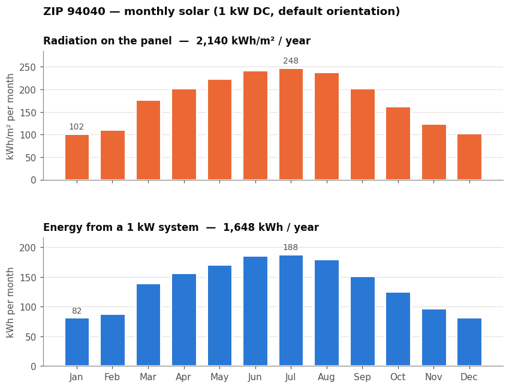

|  | Jan | Feb | Mar | Apr | May | Jun | Jul | Aug | Sep | Oct | Nov | Dec |
| --- | --- | --- | --- | --- | --- | --- | --- | --- | --- | --- | --- | --- |
| radiation kWh/m² | 101.9 | 111.6 | 177.4 | 202.7 | 223.9 | 242.7 | 247.8 | 239.2 | 202.9 | 163.0 | 124.0 | 102.8 |
| radiation kWh/m²/day | 3.3 | 4.0 | 5.7 | 6.8 | 7.2 | 8.1 | 8.0 | 7.7 | 6.8 | 5.3 | 4.1 | 3.3 |
| energy kWh (1 kW) | 81.8 | 87.7 | 139.4 | 156.9 | 171.4 | 186.0 | 188.2 | 180.0 | 151.7 | 125.5 | 97.5 | 82.4 |

```python
def plot_monthly(site, title):
    poa, ac = np.array(site['poa_monthly']), np.array(site['ac_monthly'])
    fig, (a1, a2) = plt.subplots(2, 1, figsize=(9, 6.2), sharex=True, gridspec_kw={'hspace': .45})
    x = np.arange(12)
    for ax, vals, color, name, unit, total in [
            (a1, poa, SUN, 'Radiation on the panel', 'kWh/m² per month', poa.sum()),
            (a2, ac, ENERGY, 'Energy from a 1 kW system', 'kWh per month', ac.sum())]:
        ax.bar(x, vals, width=.72, color=color, edgecolor='white', linewidth=2)
        ax.set_title(f'{name}  —  {total:,.0f} {unit.split(" per")[0]} / year', pad=8)
        ax.set_ylabel(unit); ax.grid(axis='x', visible=False)
        for i in (int(vals.argmax()), int(vals.argmin())):          # selective labels: max & min
            ax.annotate(f'{vals[i]:.0f}', (i, vals[i]), xytext=(0, 3), textcoords='offset points',
                        ha='center', va='bottom', fontsize=9, color=INK2)
        ax.set_ylim(0, vals.max() * 1.15)
    a2.set_xticks(x, MONTHS)
    fig.suptitle(title, x=.125, ha='left', fontsize=12, fontweight='bold', y=.99)
    plt.show()

plot_monthly(SITE, f'ZIP {ZIP} — monthly solar (1 kW DC, default orientation)')

# table view (the numbers behind the bars)
pd.DataFrame({'radiation kWh/m²': SITE['poa_monthly'],
              'radiation kWh/m²/day': SITE['solrad_monthly'],
              'energy kWh (1 kW)': SITE['ac_monthly']}, index=MONTHS).round(1).T
```

## 2. Average day for each month (1 kW system)

Each curve is one month's **average day**: the energy produced in each hour (kWh in that hour = average kW). Hours are **clock time** — PVWatts reports standard time, so March–October are shifted one hour for daylight saving. The shaded band is the **4–9pm peak**: the solar output that lands there is small, which is why a battery (charged at midday, discharged 4–9pm) matters. Darker = closer to the June solstice; Jan–Jun solid, Jul–Dec dashed.

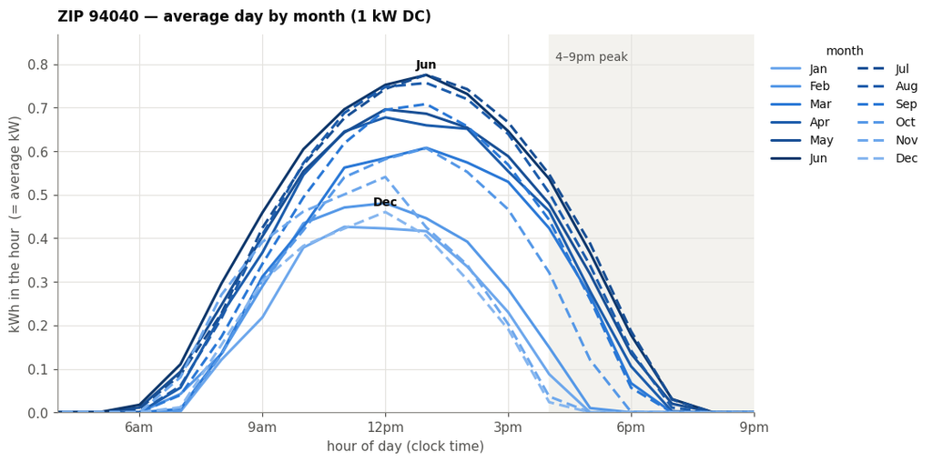

|  | Jan | Feb | Mar | Apr | May | Jun | Jul | Aug | Sep | Oct | Nov | Dec |
| --- | --- | --- | --- | --- | --- | --- | --- | --- | --- | --- | --- | --- |
| kWh/day (avg day) | 2.64 | 3.13 | 4.50 | 5.23 | 5.53 | 6.20 | 6.07 | 5.81 | 5.06 | 4.05 | 3.25 | 2.66 |
| peak hour output kW | 0.43 | 0.48 | 0.61 | 0.68 | 0.70 | 0.78 | 0.78 | 0.76 | 0.71 | 0.61 | 0.54 | 0.46 |
| share in 4–9pm | 3.3% | 5.1% | 16.9% | 16.2% | 17.2% | 17.9% | 19.0% | 17.1% | 15.0% | 10.9% | 1.1% | 0.9% |

```python
def plot_avg_day(site, title):
    day = avg_day(site)
    fig, ax = plt.subplots(figsize=(9.5, 5.2))
    ax.axvspan(PEAK[0], PEAK[1], color=PEAKFILL, zorder=0)
    ax.text(PEAK[0] + .15, day.max() * 1.07, '4–9pm peak', color=INK2, fontsize=9, va='top')
    hours = np.arange(24)
    for m in range(12):
        ax.plot(hours, day[m], color=month_color(m), ls=month_style(m), lw=2, label=MONTHS[m],
                solid_capstyle='round')
    for m in (5, 11):                                                   # direct labels: Jun, Dec
        h = int(day[m].argmax())
        ax.annotate(MONTHS[m], (h, day[m, h]), xytext=(0, 5), textcoords='offset points',
                    ha='center', fontsize=9, color=INK, fontweight='bold')
    ax.set_xticks(range(0, 25, 3), [f'{h % 12 or 12}{"am" if h % 24 < 12 else "pm"}' for h in range(0, 25, 3)])
    ax.set_xlim(4, 21); ax.set_ylim(0, day.max() * 1.12)
    ax.set_xlabel('hour of day (clock time)'); ax.set_ylabel('kWh in the hour  (= average kW)')
    ax.set_title(title, pad=10)
    ax.legend(ncol=2, frameon=False, fontsize=9, loc='upper left', bbox_to_anchor=(1.01, 1),
              title='month', title_fontsize=9, handlelength=2.4)
    plt.show()
    peak_share = np.array([day[m, PEAK[0]:PEAK[1]].sum() / day[m].sum() for m in range(12)])
    return pd.DataFrame({'kWh/day (avg day)': day.sum(1), 'peak hour output kW': day.max(1),
                         'share in 4–9pm': peak_share}, index=MONTHS).T

plot_avg_day(SITE, f'ZIP {ZIP} — average day by month (1 kW DC)').style.format('{:.2f}').format(
    '{:.1%}', subset=pd.IndexSlice['share in 4–9pm', :])
```

## 3. ZIP-level table vs the zone fallback

Only meaningful for a harvested ZIP. Each panel is one month's average day: **blue** = this ZIP's table, **gray** = the CEC-zone station table that any un-harvested ZIP in the zone would use.

> **Read the annual difference, not single months.** PVWatts weather is a *typical meteorological year* (TMY) per ~4 km weather cell, stitched month-by-month from different historical years. Two nearby cells can pick a cloudier February from different years, so single months can differ by 5–12% even when the annual totals match within 1%.

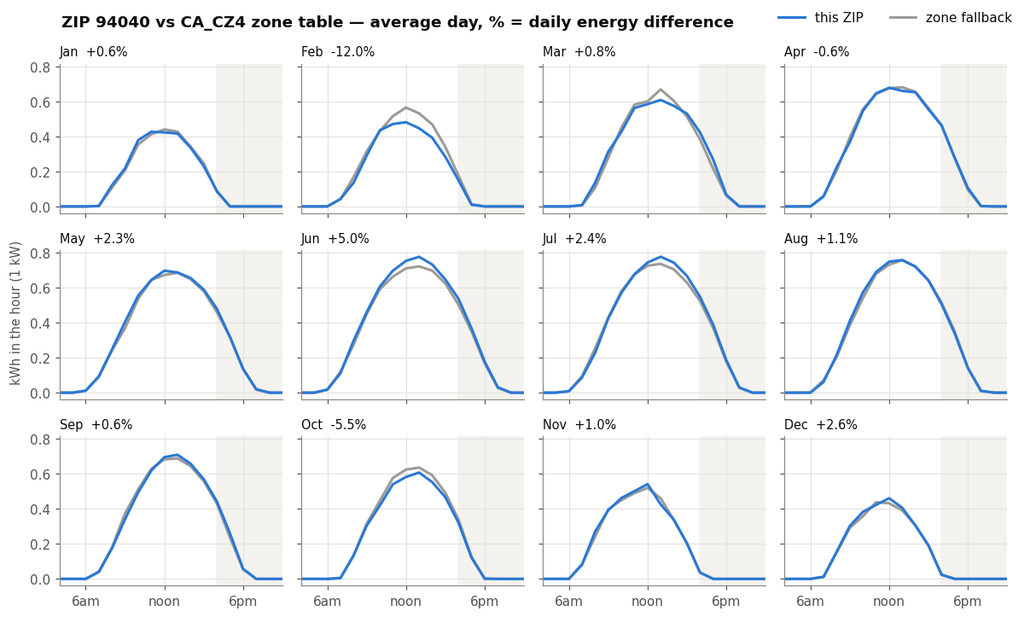

```python
def plot_vs_zone(site, zone_site, title):
    a, b = avg_day(site), avg_day(zone_site)
    fig, axes = plt.subplots(3, 4, figsize=(11, 6.6), sharex=True, sharey=True)
    for m, ax in enumerate(axes.flat):
        ax.axvspan(*PEAK, color=PEAKFILL, zorder=0)
        ax.plot(range(24), b[m], color=REF, lw=2)
        ax.plot(range(24), a[m], color=ENERGY, lw=2)
        d = a[m].sum() / b[m].sum() - 1
        ax.set_title(f'{MONTHS[m]}  {d:+.1%}', fontsize=9.5, fontweight='normal', color=INK)
        ax.set_xlim(4, 21); ax.set_xticks([6, 12, 18], ['6am', 'noon', '6pm'])
    fig.legend([Line2D([], [], color=ENERGY, lw=2), Line2D([], [], color=REF, lw=2)],
               ['this ZIP', 'zone fallback'], loc='upper right', ncol=2, frameon=False)
    fig.suptitle(title, x=.07, ha='left', fontsize=12, fontweight='bold')
    fig.supylabel('kWh in the hour (1 kW)', color=INK2, fontsize=9.5)
    fig.tight_layout(); plt.show()

if LEVEL == 'zip':
    plot_vs_zone(SITE, ZONE_SITE, f'ZIP {ZIP} vs {zone} zone table — average day, % = daily energy difference')
else:
    print(f'ZIP {ZIP} has no ZIP-level table yet — it uses the {zone} zone table directly.')
```

## 4. All harvested ZIPs at a glance

Annual yield per ZIP against its zone table (sorted), with the 4–9pm share of July output.

```python
rows = []
for z, e in PV['zips'].items():
    s, zs = PV['sites'][e['site']], PV['sites'][PV['zones'][e['zone']]['site']]
    jul = avg_day(s)[6]
    rows.append({'ZIP': z, 'region': e['region'], 'zone': e['zone'],
                 'selected because': REG[e['region']]['zips'][z]['reason'],
                 'kWh/kW/yr': s['ac_annual'], 'vs zone': s['ac_annual'] / zs['ac_annual'] - 1,
                 '4 kW kWh/yr': 4 * s['ac_annual'], 'Jul 4–9pm share': jul[PEAK[0]:PEAK[1]].sum() / jul.sum()})
df = pd.DataFrame(rows).sort_values('vs zone').reset_index(drop=True)
df.style.format({'kWh/kW/yr': '{:,.0f}', '4 kW kWh/yr': '{:,.0f}', 'vs zone': '{:+.1%}',
                 'Jul 4–9pm share': '{:.1%}'})
```

|  | ZIP | region | zone | selected because | kWh/kW/yr | vs zone | 4 kW kWh/yr | Jul 4–9pm share |
| --- | --- | --- | --- | --- | --- | --- | --- | --- |
| 0 | 95046 | svce | CA_CZ4 | unincorporated 98% | 1,596 | -2.9% | 6,385 | 18.6% |
| 1 | 95020 | svce | CA_CZ4 | member: Gilroy city 11% | 1,609 | -2.1% | 6,436 | 19.0% |
| 2 | 95032 | svce | CA_CZ4 | member: Los Gatos town 46% | 1,617 | -1.7% | 6,468 | 18.8% |
| 3 | 95033 | svce | CA_CZ4 | unincorporated 98% | 1,621 | -1.4% | 6,486 | 18.8% |
| 4 | 94301 | svce | CA_CZ4 | enclave: Palo Alto city 100% | 1,633 | -0.7% | 6,530 | 19.4% |
| 5 | 95035 | svce | CA_CZ4 | member: Milpitas city 60% | 1,634 | -0.6% | 6,535 | 18.5% |
| 6 | 94303 | svce | CA_CZ4 | enclave: Palo Alto city 61% | 1,634 | -0.6% | 6,538 | 18.6% |
| 7 | 95030 | svce | CA_CZ4 | member: Los Gatos town 29% | 1,638 | -0.3% | 6,554 | 18.8% |
| 8 | 95054 | svce | CA_CZ4 | enclave: Santa Clara city 99% | 1,639 | -0.3% | 6,556 | 18.9% |
| 9 | 95050 | svce | CA_CZ4 | enclave: Santa Clara city 96% | 1,644 | +0.0% | 6,576 | 18.5% |
| 10 | 94086 | svce | CA_CZ4 | member: Sunnyvale city 100% | 1,648 | +0.2% | 6,591 | 18.6% |
| 11 | 94087 | svce | CA_CZ4 | member: Sunnyvale city 100% | 1,648 | +0.2% | 6,591 | 18.6% |
| 12 | 94085 | svce | CA_CZ4 | member: Sunnyvale city 98% | 1,648 | +0.2% | 6,591 | 18.6% |
| 13 | 94024 | svce | CA_CZ4 | member: Los Altos city 46% | 1,648 | +0.3% | 6,594 | 19.0% |
| 14 | 94040 | svce | CA_CZ4 | member: Mountain View city 100% | 1,648 | +0.3% | 6,594 | 19.0% |
| 15 | 94089 | svce | CA_CZ4 | member: Sunnyvale city 100% | 1,648 | +0.3% | 6,594 | 18.9% |
| 16 | 95037 | svce | CA_CZ4 | member: Morgan Hill city 10% | 1,649 | +0.3% | 6,594 | 18.2% |
| 17 | 94306 | svce | CA_CZ4 | enclave: Palo Alto city 100% | 1,649 | +0.3% | 6,597 | 18.6% |
| 18 | 95053 | svce | CA_CZ4 | enclave: Santa Clara city 100% | 1,655 | +0.6% | 6,619 | 18.5% |
| 19 | 94043 | svce | CA_CZ4 | member: Mountain View city 72% | 1,656 | +0.7% | 6,625 | 19.0% |
| 20 | 94304 | svce | CA_CZ4 | enclave: Palo Alto city 80% | 1,657 | +0.8% | 6,628 | 19.0% |
| 21 | 95051 | svce | CA_CZ4 | enclave: Santa Clara city 98% | 1,659 | +0.9% | 6,635 | 18.6% |
| 22 | 94041 | svce | CA_CZ4 | member: Mountain View city 100% | 1,659 | +0.9% | 6,638 | 19.0% |
| 23 | 95008 | svce | CA_CZ4 | member: Campbell city 88% | 1,660 | +1.0% | 6,639 | 18.7% |
| 24 | 94305 | svce | CA_CZ4 | unincorporated 100% | 1,663 | +1.1% | 6,651 | 19.2% |
| 25 | 94022 | svce | CA_CZ4 | member: Los Altos Hills town 42% | 1,676 | +1.9% | 6,703 | 18.9% |
| 26 | 95070 | svce | CA_CZ4 | member: Saratoga city 45% | 1,679 | +2.2% | 6,718 | 18.5% |
| 27 | 95014 | svce | CA_CZ4 | member: Cupertino city 44% | 1,710 | +4.0% | 6,840 | 18.4% |
| 28 | 95140 | svce | CA_CZ4 | unincorporated 100% | 1,752 | +6.6% | 7,007 | 18.0% |

### Try it live (optional)

Interactive ZIP box — works in Jupyter, not in the exported HTML.

```python
from ipywidgets import interact, Text
def live(zipcode='95140'):
    s, level, how = resolve(zipcode)
    print(f'ZIP {zipcode}: {how} · {s["ac_annual"]:,.0f} kWh/kW/yr')
    plot_monthly(s, f'ZIP {zipcode} — monthly solar (1 kW)')
    plot_avg_day(s, f'ZIP {zipcode} — average day by month (1 kW)')
interact(live, zipcode=Text('95140', description='ZIP'));
```